# Next Word Prediction

Tejash Panchal  
4/18/2016

### Objective

Natural Language Processing field is growing rapidly. Various companies are providing creative ways to reduce/eliminate the need for typing which is very helpful especially with small screen devices without keybords.

The intent of this application is as below:

- Provide user with top 5 hint of current words.
- Provide user with top 5 suggested next words.
- Future enhencement will allow user to choose word from hint/suggested word which will eliminate need for typing full text.

### Algorithms Supported

This application will use algorithms below to achieve its objective.

- Maximum Likelyhood Estimates:

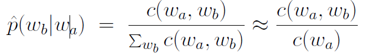

- Laplace estimate:

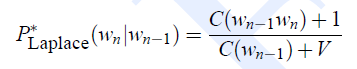

- Good Turing (Default)
- Simple Interpolation

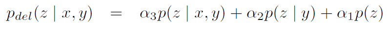

### Application Instructions

- This application provides hint for current word as you start typing.
- This application also provides suggestion for next word once spacebar is pressed.
- User can use this application by typing text in “Text Input” box located in “User Input Area”.
- Click “Clear!” button to clear the text in “Text Input:” area.
- For selected smoothing algorithm, the program will perform the probability calculations and displays top 5 suggested words for next word or top 5 hints for current word in table located in “Next Word Suggestion” area.
- Application can be executed at [ShinyApps.io](https://tpanchal.shinyapps.io/WordPrediction/)
- Source code is available on [GitHub](https://github.com/tpanchal68/WordPrediction)

### Current UI and Future Enhencements

- Look and feel for UI:

[figure not shown]

- Add functionality so user can click the word and it will be pasted on the sentence.
- Add support for kneser ney smoothing algorithm.
- Enhanced error handling.
- Add support for new tokens as sentence completes in text input line.